# KDE

# Introduction and Basic Math

Kernel Density Estimation is a non-parametric method of estimating the PDF of random variable. It is useful when inferences about a population are made, based on a finite sample.<sup>1</sup> It is, fundamentally, a smoothing problem. More simplistic non-parametric techniques, such as the histogram, often exhibit discontinuities not due to the underlying density. KDE solves this problem by allowing smooth, continuous kernels to be used.

Definitions<sup>2</sup>:  
A *kernel function* $k(u):\mathbb{R} \rightarrow \mathbb{R}$ is any function which satisfies $\int_{-\infty}^\infty k(u) du = 1.$

A *non-negative* kernel satisfies $k(u) \geq 0$ for all $u$. In this case, $k(u)$ is a probability density function.

A *symmetric* kernel function satisfies $k(u) = k(-u)$ for all $u$.

Now we derive the basic form of the kernel density estimate.<sup>3</sup>

The probability that a vector $x$, drawn from a distribution $p(x)$, will fall in a given region $\mathcal{R}$ of the sample space is $P = \int_\mathcal{R} p(x')dx'.$ Now suppose that $N$ vectors $\{x_1, x_2, \dots x_N\}$ are drawn from the distribution. The probability that $k$ of these $N$ vectors fall in $\mathcal{R}$ is given by the binomial distribution $P(k) = {N}\choose{k} P^k(1-P)^{N-k}.$ It can be shown that the mean and variance of the ratio $k/N$ are $P$ and $\frac{P(1-P)}{N}$, respectively. Consequently, as $N\rightarrow \infty$ the variance decreases, we we can respect that a good estimate of the probability $P$ can be obtained from the mean fraction of the points that fall within $\mathcal{R}$ $P\cong \frac{k}{N}.$ Alternatively, if we assume that $\mathcal{R}$ is so small that $p(x)$ doesn’t vary much within it, then $\int_\mathcal{R} p(x')dx' \cong p(x)V$ (where $V$ is the volume enclosed by $\mathcal{R}$). Merging these two results demonstrates that $p(x) \cong \frac{k}{NV}.$

In practice, $N$ is fixed. We could improve the accuracy of $p(x)$ by restricting $V$, but then $\mathcal{R}$ would become so small that no examples would be enclosed. This parallels the issue of bin width selection in histogram modelling. In practice, we have to find a compromise for $V$ that is large enough to include examples within $\mathcal{R}$ and small enough to support the assumption that $p(x)$ is constant within $\mathcal{R}$. Kernel Density Estimation arises when we find $V$ and determine $k$ from the data. As a fun aside, K-nearest-neighbor arises when we fix k and determine $V$ from the data.

Letting $K(\cdot)$ be a kernel. We can determine that the density at a location $x$ is $p_{KDE}(x) = \frac{1}{Nh^D}\sum_{n=1}^NK(\frac{x-x_k}{h}).$ There are a number of common Kernels: uniform, triangular, bi weight, triweight, Epanechnikov, normal, etc. Though the Epanechnikov is the optimal with regard to MSE, I use a normal kernel for my function. For a normal kernel function $K(u) = \frac{1}{ \sqrt{2 \pi }}e^{-\frac{1}{2}u^2}.$

# Packages!!!

```r
library(MASS)
library(graphics)
library(mvtnorm)
```

# One-Dimensional Case

I have one function for the one-dimensional case.

```r
myKDE1 <- function(d, bw){
  n <- length(d)
  my_bins <- c(rep(NA, 1000))
  my_heights <- c(rep(NA, 1000))
  step <- (max(d) + 5 - (min(d) - 5)) / 1000
  pos <- min(d) - 5
  for(i in 1:length(my_bins)){
    height <- 0
    for(x in d){
      height <- height + 1/sqrt(2*pi)*exp(-1/2*((pos-x)/bw)^2)
    }
    height <- height / (n * bw)
    my_bins[i] <- pos
    my_heights[i] <- height
    pos <- pos + step
  }
  my_points <- cbind(my_bins, my_heights)
  return(my_points)
}
```

And some test cases. In this first case I compare my results to the results of density() with my selected bw.

First, so we can be consistent, I’m going to set all my data:

```r
set.seed(306)

x <- rgamma(30, 3, 4) # 1D

y <- rexp(30, 4)

df <- data.frame(x, y) # 2D
```

```r
bw_x <- ucv(x)
bw_x
```

```
## [1] 0.6765296
```

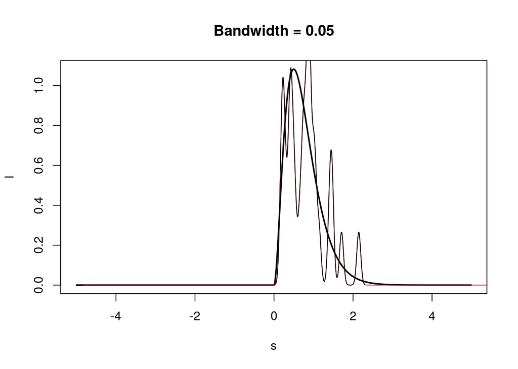

```r
l <- rep(NA, 1000)
s <- rep(NA, 1000)
step <- 1/100
pos <- -5
for(i in 1:1000){
  l[i] = dgamma(pos, 3, 4)
  s[i] <- pos
  pos <- pos + step
}
plot(l ~ s, type = "l", lwd = 2, main = "Bandwidth = 0.05")
lines(myKDE1(x, 0.05), col = "red")
lines(density(x, bw = 0.05))
```

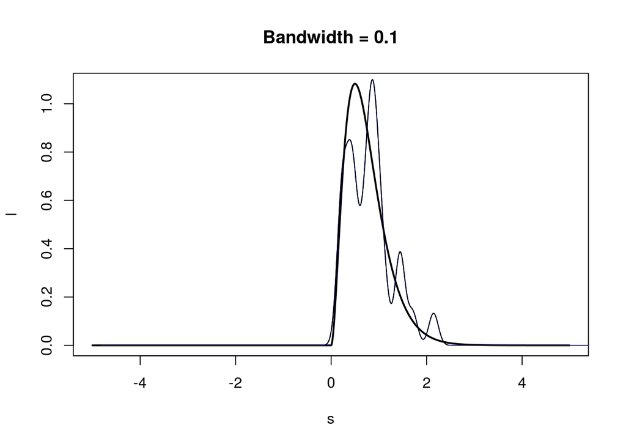

```r
plot(l ~ s, type = "l", lwd = 2, main = "Bandwidth = 0.1")
lines(myKDE1(x, 0.1), col = "blue")
lines(density(x, bw = 0.1))
```

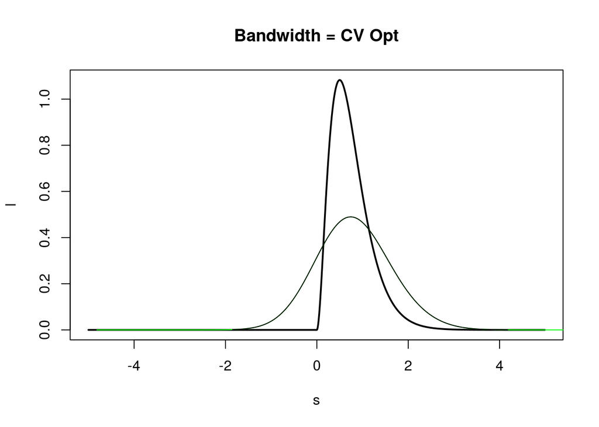

```r
plot(l ~ s, type = "l", lwd = 2, main = "Bandwidth = CV Opt")
lines(myKDE1(x, bw_x), col = "green")
lines(density(x, bw = bw_x))
```

For the following, I only include the results.

```r
bw_y <- ucv(y)
bw_y
```

```
## [1] 0.2376241
```

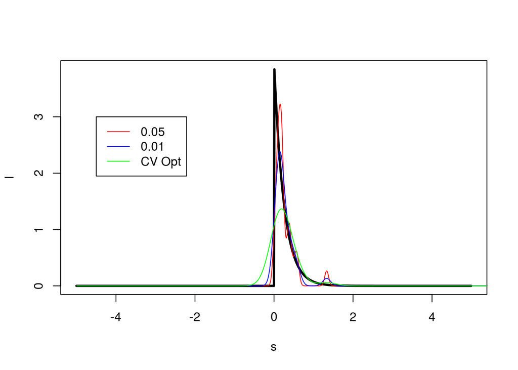

```r
l <- rep(NA, 1000)
s <- rep(NA, 1000)
step <- 1/100
pos <- -5
for(i in 1:1000){
  l[i] <- dexp(pos, 4)
  s[i] <- pos
  pos <- pos + step
}
plot(l ~ s, type = "l", lwd = 3)
legend(-4.5, 3, c(0.05, 0.01, "CV Opt"), col = c("red", "blue", "green"), lty = c(1, 1, 1))
lines(myKDE1(y, 0.05), col = "red")
lines(myKDE1(y, 0.1), col = "blue")
lines(myKDE1(y, bw_y), col = "green")
```

```r
z <- rnorm(100, 0, 1)
bw_z <- ucv(z)
bw_z
```

```
## [1] 0.1985607
```

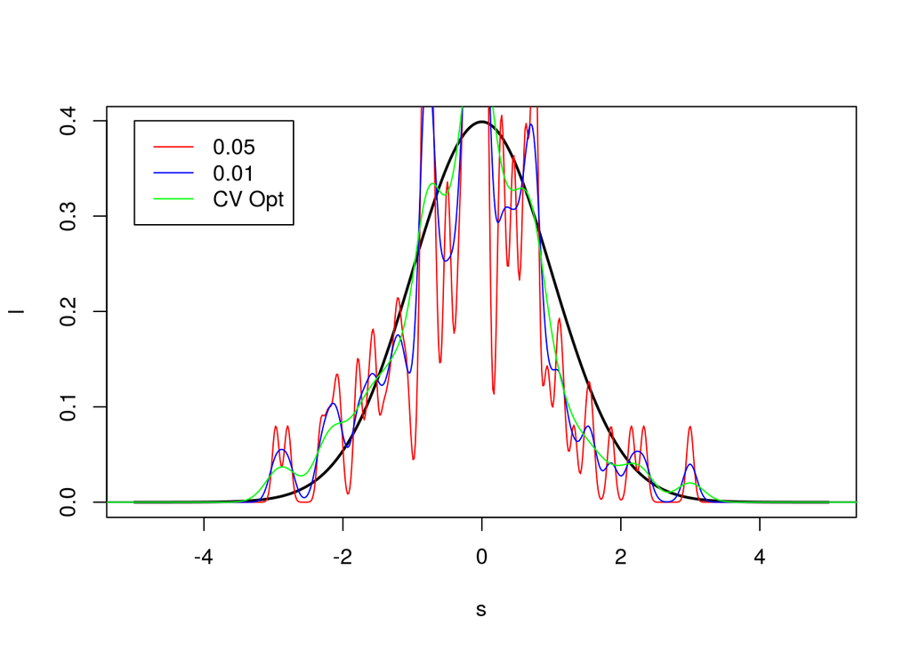

```r
my_points <- myKDE1(z, 0.05)
l <- rep(NA, 1000)
s <- rep(NA, 1000)
step <- 1/100
pos <- -5
for(i in 1:1000){
  l[i] = dnorm(pos)
  s[i] <- pos
  pos <- pos + step
}
plot(l ~ s, type = "l", lwd = 2)
legend(-5, 0.4, c(0.05, 0.01, "CV Opt"), col = c("red", "blue", "green"), lty = c(1, 1, 1))
lines(myKDE1(z, 0.05), col = "red")
lines(myKDE1(z, 0.1), col = "blue")
lines(myKDE1(z, bw_z), col = "green")
```

# Two-Dimensional Case

For the two-dimensional case, I have included two functions. One assumes kernel independence and the other assumes factor-independence.

```r
myKDE2_KI <- function(d, bw){
  get_height <- function(x, y, d, bw){
    height <- 0
    for(i in 1:nrow(d)){
       height <- height + 1/sqrt(2*pi)*exp(-1/2*((x-d[i,1])/bw[1])^2)*1/sqrt(2*pi)*exp(-1/2*((y-d[i,2])/bw[2])^2)
    }
    height <- height/prod(nrow(d), bw)
    return(height)
  }
  x = seq(min(d[,1]) - 2, max(d[,1])+2, length.out = 50)
  y = seq(min(d[,2]) - 2, max(d[,2])+2, length.out = 50)
  heights <- matrix(rep(NA, length(x)* length(y)), nrow = length(x), byrow = T)
  for(i in 1:length(x)){
    for(j in 1:length(y)){
      heights[i, j] <- get_height(x[i], y[j],d, bw)
    }
  }
  contour(x, y, heights)
}


myKDE2_FI <- function(d, bw){
  get_height <- function(p, d, bw){
    height <- 0
    for(datum in d){
      height <- height + 1/sqrt(2*pi)*exp(-1/2*((p-datum)/bw)^2)
    }
    height <- height/prod(length(d), bw)
    return(height)
  }
  x = seq(min(d[,1]) - 2, max(d[,1])+2, length.out = 100)
  y = seq(min(d[,2]) - 2, max(d[,2])+2, length.out = 100)
  heights <- matrix(rep(NA, length(x)* length(y)), nrow = length(x), byrow = T)
  for(i in 1:length(x)){
    for(j in 1:length(y)){
      heights[i, j] <- get_height(x[i], d[,1], bw[1]) * get_height(y[j], d[,2], bw[2])
    }
  }
  contour(x, y, heights)
}
```

Now to test it out! We have $x$ and $y$ distributed as before.

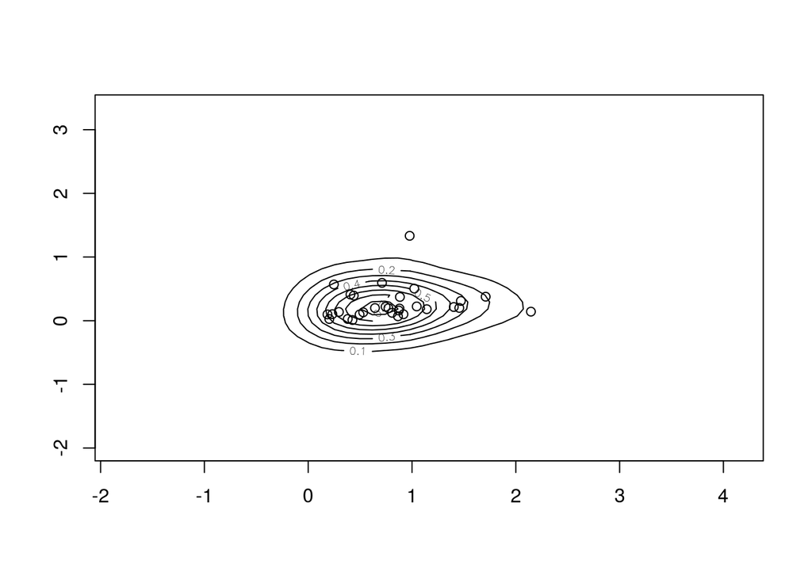

```r
myKDE2_KI(data.frame(x, y), c(0.3, 0.3))
points(data.frame(x, y))
```

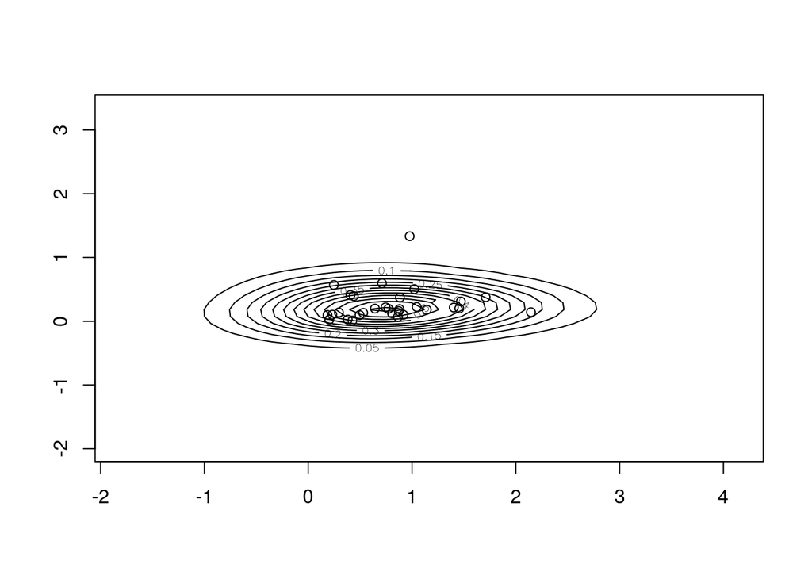

```r
myKDE2_KI(data.frame(x, y), c(bw_x, bw_y))
points(data.frame(x, y))
```

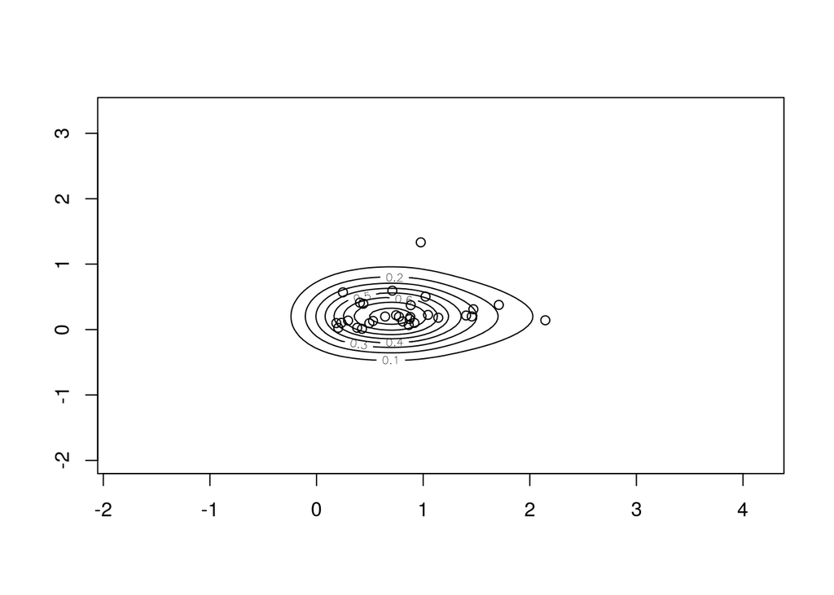

```r
myKDE2_FI(data.frame(x, y), c(0.3, 0.3))
points(data.frame(x, y))
```

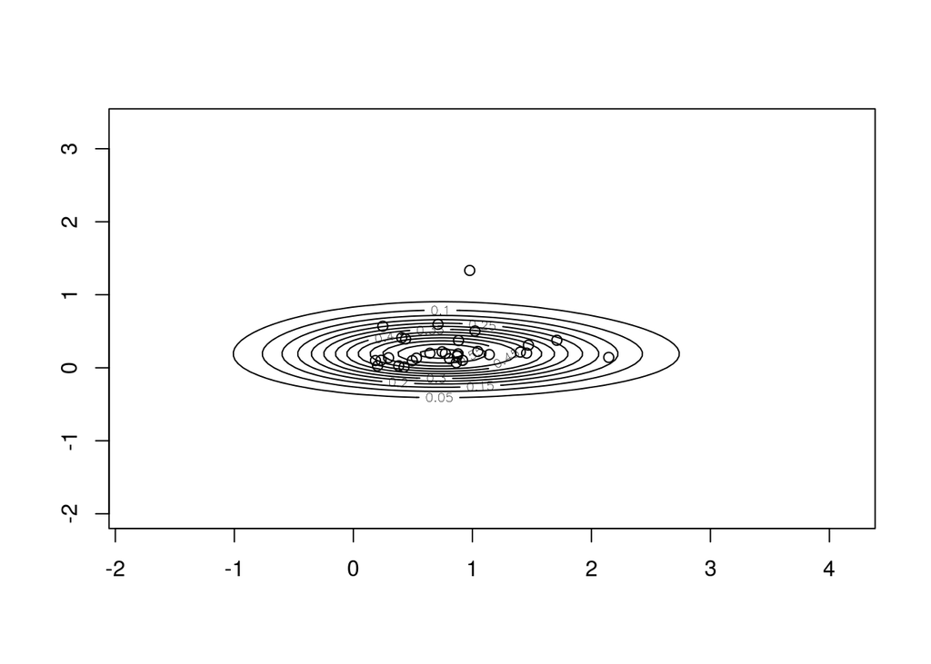

```r
myKDE2_FI(data.frame(x, y), c(bw_x, bw_y))
points(data.frame(x, y))
```

We reset $a$ and create a new normal $b$.

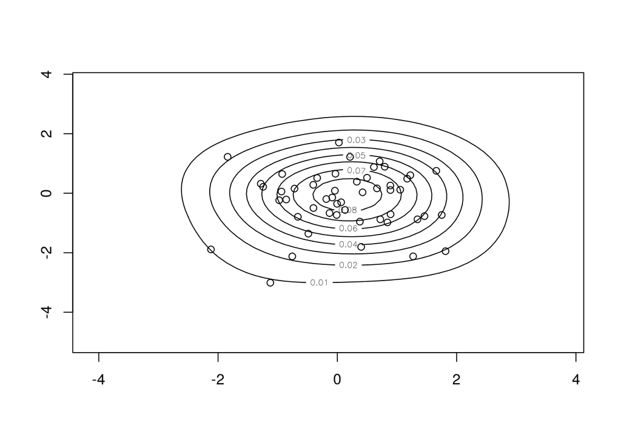

```r
a <- rnorm(50)
b <- rnorm(50)
bw_a <- ucv(a)
bw_b <- ucv(b)
par(mfrow = c(1, 1))

myKDE2_KI(data.frame(a, b), c(1, 1))
points(data.frame(a, b))
```

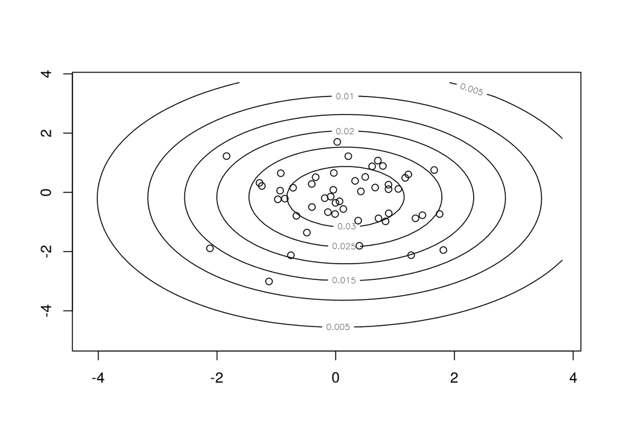

```r
myKDE2_KI(data.frame(a, b), c(bw_a, bw_b))
points(data.frame(a, b))
```

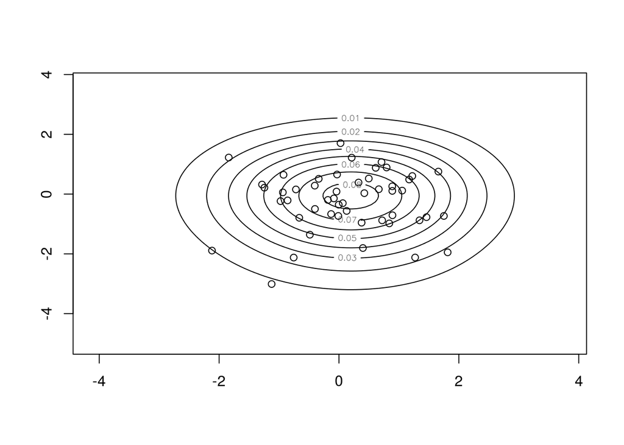

```r
myKDE2_FI(data.frame(a, b), c(1, 1))
points(data.frame(a, b))
```

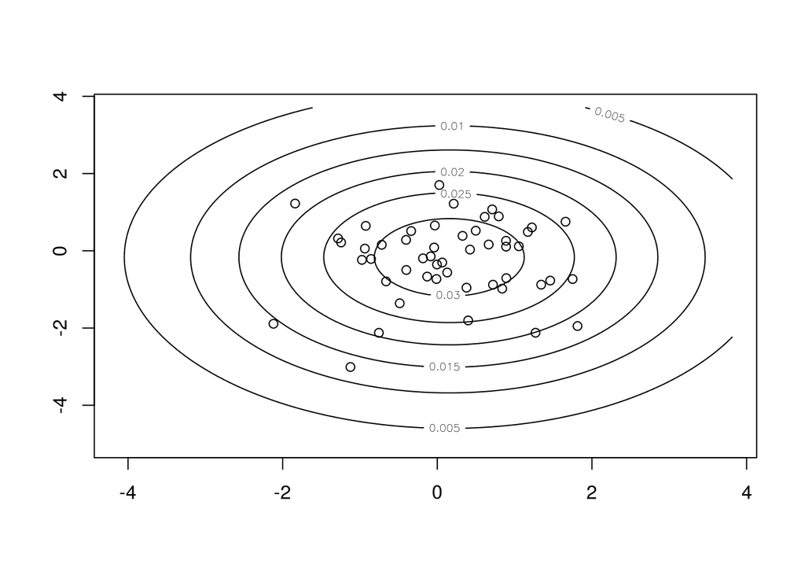

```r
myKDE2_FI(data.frame(a, b), c(bw_a, bw_b))
points(data.frame(a, b))
```

# Bandwidth Selection through Cross-Validation

I’m lazy, so I just found a function on CRAN that would use cross-validation to for optimal bandwidth selection. I would like to work more to figure it out, but didn’t realize it’s complexity in time.